# getVOT

PhonPhon, Aarhus University  
8/6/2023

## What is voice onset time?

- The relative time between the release burst of a stop \(rel_t\) and the onset of vocal fold vibration \(vo_t\).
- Calculated as \(vo_t - rel_t\).
- When stops are voiceless, \(rel_t\) precedes \(vo_t\) and this results in a **positive** number.
- When stops are pre-voiced, \(vo_t\) precedes \(rel_t\) and this results in a **negative** number.

## What is voice onset time?

[interactive chart not shown]

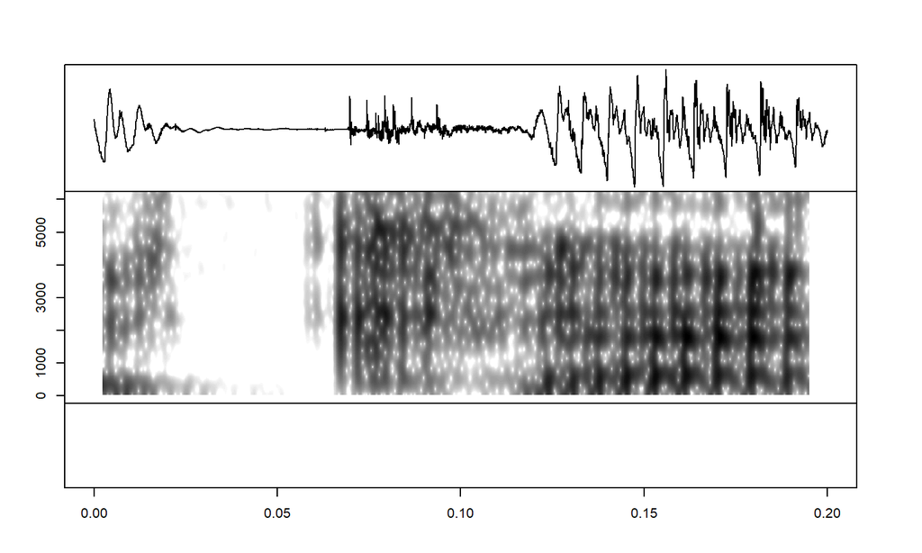

[interactive chart not shown]

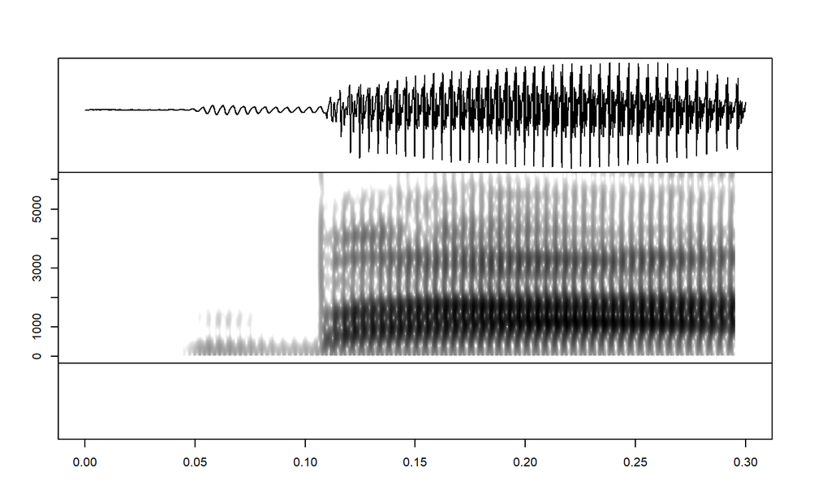

## What is voice onset time?

[interactive chart not shown]

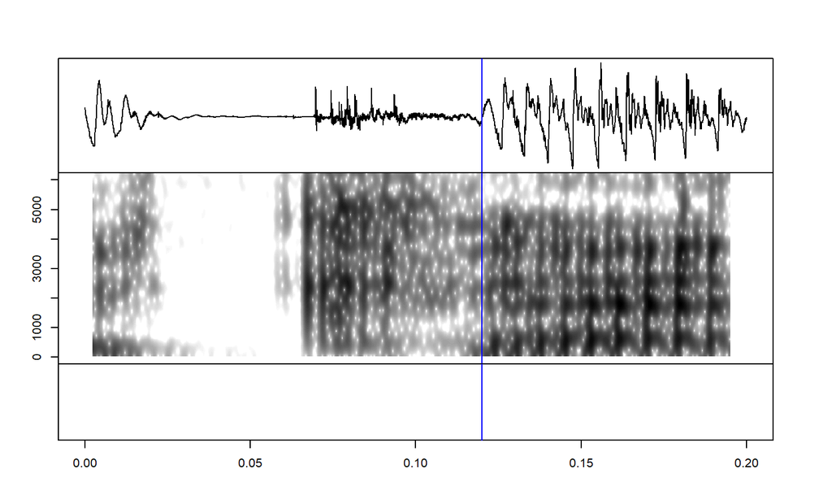

- \(rel_t\) precedes \(vo_t\).
- \(vo_t=\) 0.12

[interactive chart not shown]

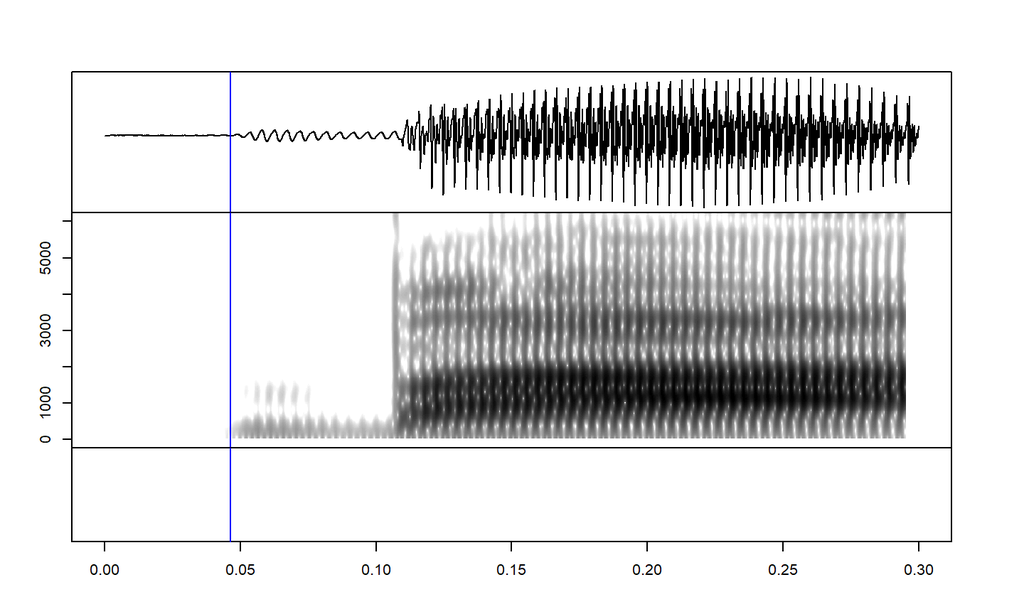

- \(vo_t\) precedes \(rel_t\).
- \(vo_t=\) 0.047

## What is voice onset time?

[interactive chart not shown]

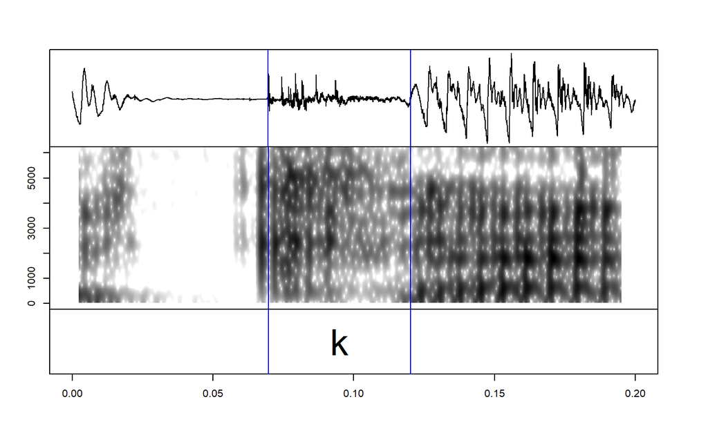

- \(rel_t\) precedes \(vo_t\).
- \(vo_t=\) 0.12
- \(rel_t=\) 0.07
- 120.1 \(-\) 69.6 \(=\) 50.5 ms.

[interactive chart not shown]

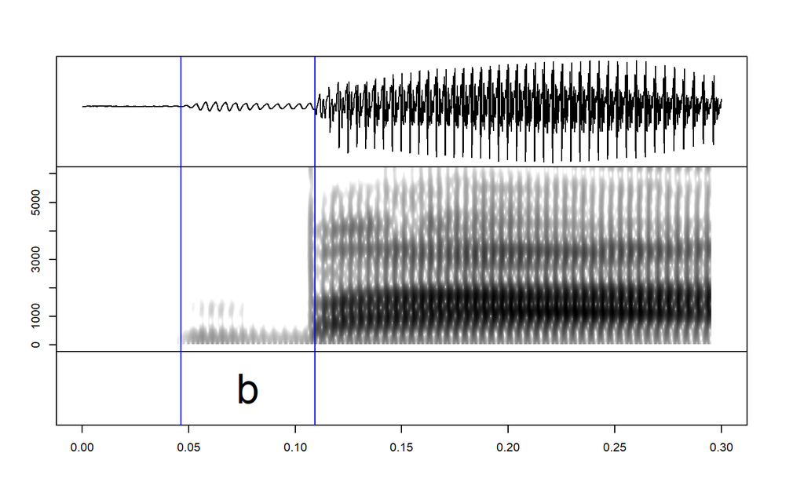

- \(vo_t\) precedes \(rel_t\).
- \(vo_t=\) 0.047
- \(rel_t=\) 0.109
- 46.5 \(-\) 109.4 \(=\) -62.9 ms.

## Why is VOT interesting?

- [Lisker & Abramson (1964)](https://doi.org/10.1080/00437956.1964.11659830) showed that VOT is the main cue to voicing contrasts in stops cross-linguistically.
  - It robustly distinguishes pre-voiced, voiceless, and voiceless aspirated stops.
- It is a major source of
  - cross-linguistic variability (e.g. [Cho & Ladefoged 1999](https://doi.org/10.1006/jpho.1999.0094))
  - and, as such, of foreign accent (e.g. [Flege 1991](https://doi.org/10.1121/1.400473))
  - by-speaker variation (e.g. [Chodroff et al. 2017](https://doi.org/10.1016/j.wocn.2017.01.001))
  - sociolinguistic variation (e.g. [Stuart-Smith et al. 2015](https://doi.org/10.1515/lp-2015-0015))
- For these reasons, it’s measured **a lot** ([Abramson & Whalen 2017](https://10.1016/j.wocn.2017.05.002)).

## Measuring VOT

- VOT is relatively easy to measure.
  - It is usually ‘hand-measured’ in e.g. [Praat](https://fon.hum.uva.nl/praat) by finding and marking landmarks in the waveform or spectrogram.
- This is a *tedious* task.
- It involves repeating the same relatively clearly defined task ad nauseum.

## Measuring VOT

- VOT is relatively easy to measure.
  - It is usually ‘hand-measured’ in e.g. [Praat](https://fon.hum.uva.nl/praat) by finding and marking landmarks in the waveform or spectrogram.
- This is a *tedious* task.
- It involves repeating the same relatively clearly defined task ad nauseum.
  - Academics are generally clever but slow.
  - This is a task for someone who’s stupid and fast.
  - **This is what computers are for**.

## Predicting VOT automatically

- There are already programs on the market that implement automatic VOT prediction.
- [AutoVOT](https://github.com/mlml/autovot) predicts positive VOT using a neural network that mimics human annotators.
  - Cannot be used with Windows.
  - Has a nice Praat plugin.
  - Scales best with a lot of representative training data.

## Predicting VOT automatically

- There are already programs on the market that implement automatic VOT prediction.
- [AutoVOT](https://github.com/mlml/autovot) predicts positive VOT using a neural network that mimics human annotators.
  - Cannot be used with Windows.
  - Has a nice Praat plugin.
  - Scales best with a lot of representative training data.
- Dr.VOT predicts positive *and* negative VOT in a similar way.
  - Cannot be used with Windows.
  - Can only be used from the command line.
  - Not clear how to add new training data.
  - Sound files can only contain a single syllable.

## Predicting VOT automatically

- `getVOT` primarily uses base `R` but optionally uses functionality from the acoustic analysis library `phonTools`.
- It should run on all operating systems.
- *Only* runs in `R`, but should be relatively straightforward to use.
- It is *not clever* – there’s no underlying neural network.
  - This may result in decreased performance.
  - It also means that there’s no black box – we know exactly what’s going on under the hood.
- Training data helps, but usually scales quite well with minimal training data.
- A bit of an intellectual exercise / coding exercise.

## Using the squiggly line…

- How I used to think of annotating VOT:
  - **I need to locate the burst or pre-voicing in the squiggly line**.

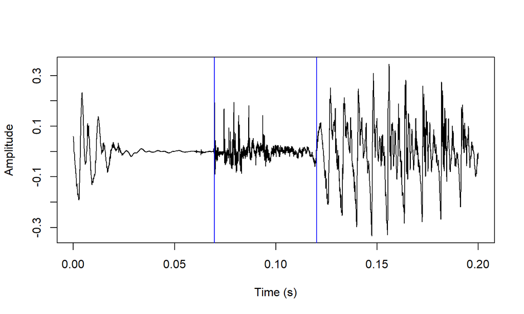

## …which is just a vector of numbers!

- That squiggly line is just a bunch of amplitude measures.

```r
snd_vl <- rPraat::snd.read('vl/firkant.wav',
                           from=0.23, to=0.43, units='seconds')
length(snd_vl$sig)
```

```
## [1] 9600
```

```r
head(snd_vl$sig[,1], 20)
```

```
##  [1]  0.059907834  0.054414502  0.052522355  0.051759392  0.051026948
##  [6]  0.050019837  0.047059542  0.040803247  0.038636433  0.038666952
## [11]  0.036530656  0.031434065  0.025788141  0.020477920  0.014435255
## [16]  0.009979553  0.004791406 -0.001007111 -0.004425184 -0.005798517
```

## …which is just a vector of numbers!

- That squiggly line is just a bunch of amplitude measures.
- With a sound file already loaded in `R`, plotting a waveform is remarkably simple.

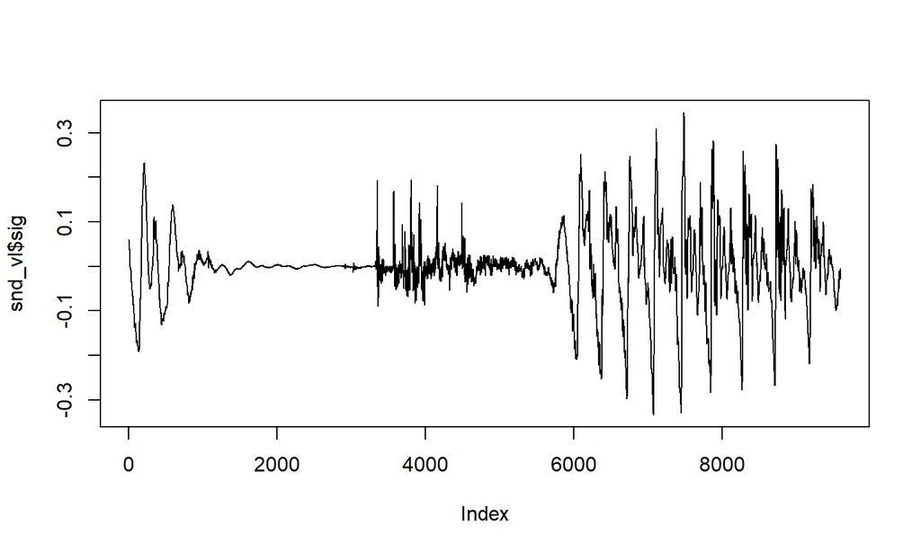

```r
plot(snd_vl$sig, type='l')
```

## …which is just a vector of numbers!

- That squiggly line is just a bunch of amplitude measures.
- With a sound file already loaded in `R`, plotting a waveform is remarkably simple.
- If we can find and annotate VOT relatively easily in the squiggly line…
  - …it should be possible to find and locate it in the vector of numbers.
- And if we find VOT using consistent landmarks…
  - …it should be possible to find it in a vector of numbers using a simple procedure.

## The procedure: positive VOT

- First: find the closure.
- Look for an interval of \(d_{clo}\) ms (e.g. 10) in the first half of the sound file with the lowest mean amplitude.

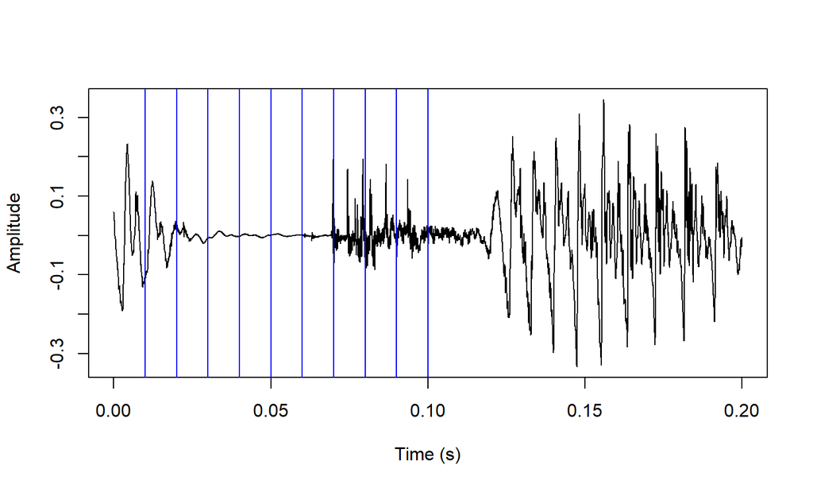

## The procedure: positive VOT

- That’s this interval.
- We look for a release after this interval.

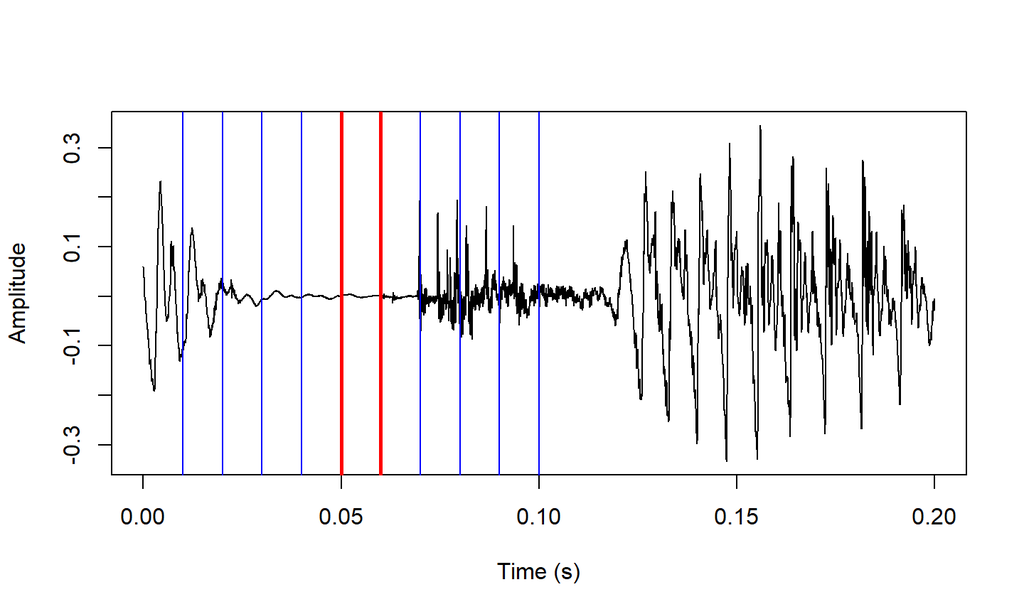

## The procedure: positive VOT

- Look for an interval of 1 ms after the closure where the maximum amplitude is higher than a \(1/p_{rel}\) (e.g. 15) proportion of the maximum amplitude in the sound.

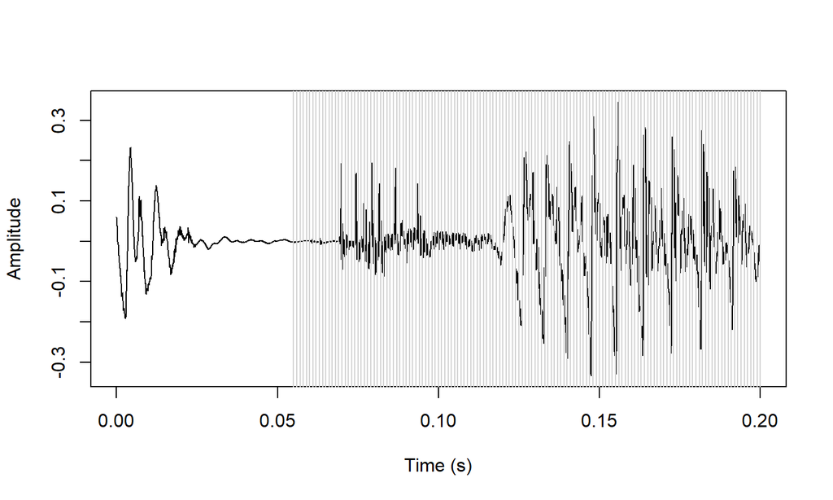

## The procedure: positive VOT

The highest amplitude starts here:

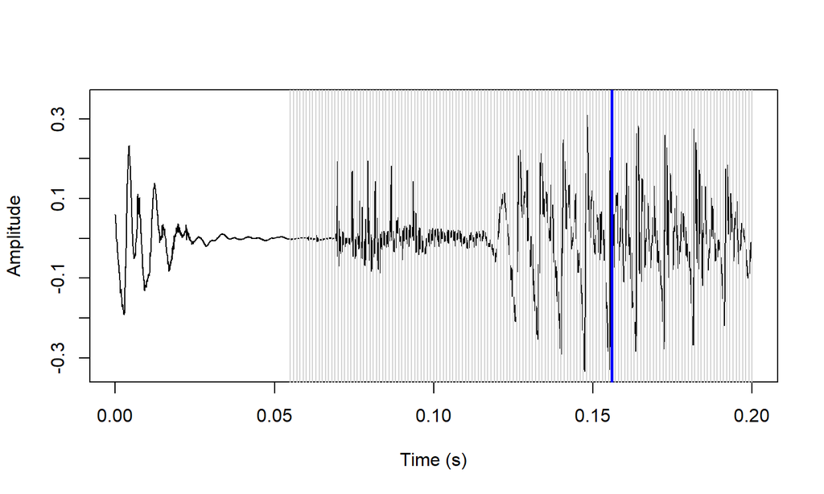

## The procedure: positive VOT

- The first interval to have maximum amplitude above \(1/p_{rel}\) of the overall maximum amplitude is this one:

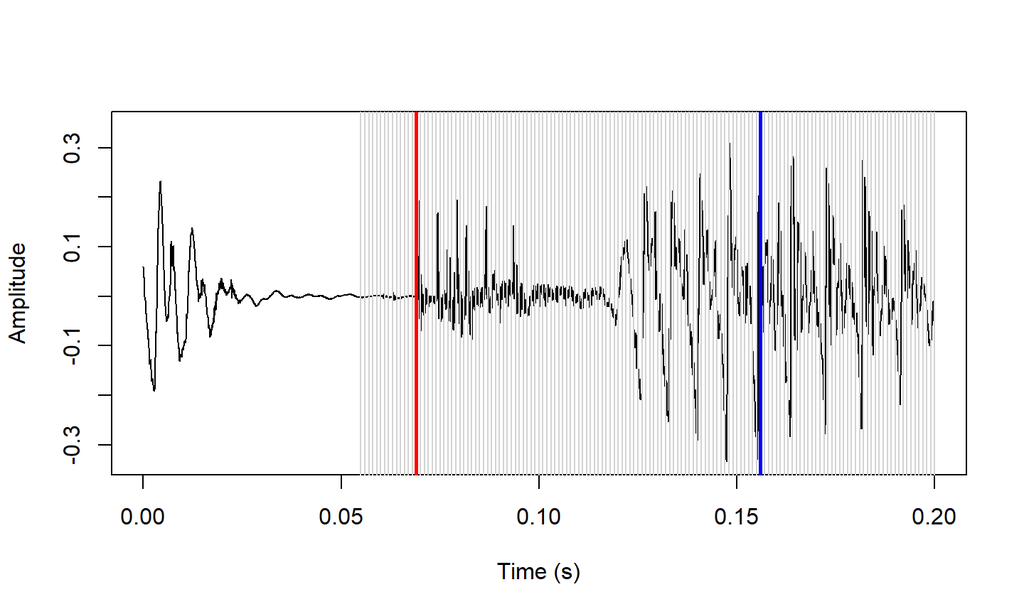

## The procedure: positive VOT

- Locating the onset of voicing is less straightforward.
- By default, we use the autocorrelation function of measures within intervals of the wave of length \(d_{vo}\) ms (e.g. 1).
  - I.e., within a 1 ms sound snippet, how correlated is each measure on average with the one that comes after?
  - Stop releases are noisy, so we do not expect consecutive measures to be highly correlated.
  - Voiced sounds such as vowels are periodic, so we expect consecutive measures to be highly correlated.
  - The voicing onset is estimated to be the first interval where autocorrelation is on average above \(p_{vo}\) % of the most autocorrelated interval in the sound.

## The procedure: positive VOT

Our intervals look like this:

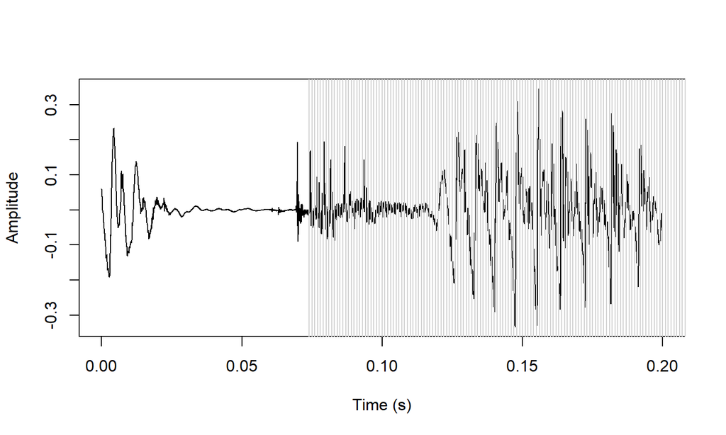

## The procedure: positive VOT

- The interval with the highest average ACF is this one:

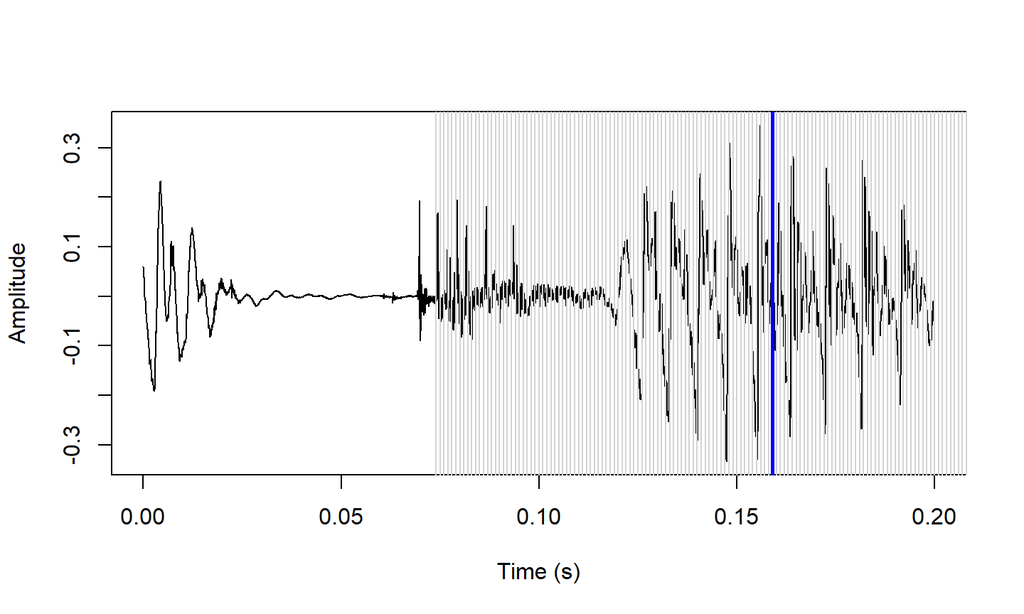

## The procedure: positive VOT

- If we zoom way in, that interval looks like this.
  - It’s quite a smooth line!

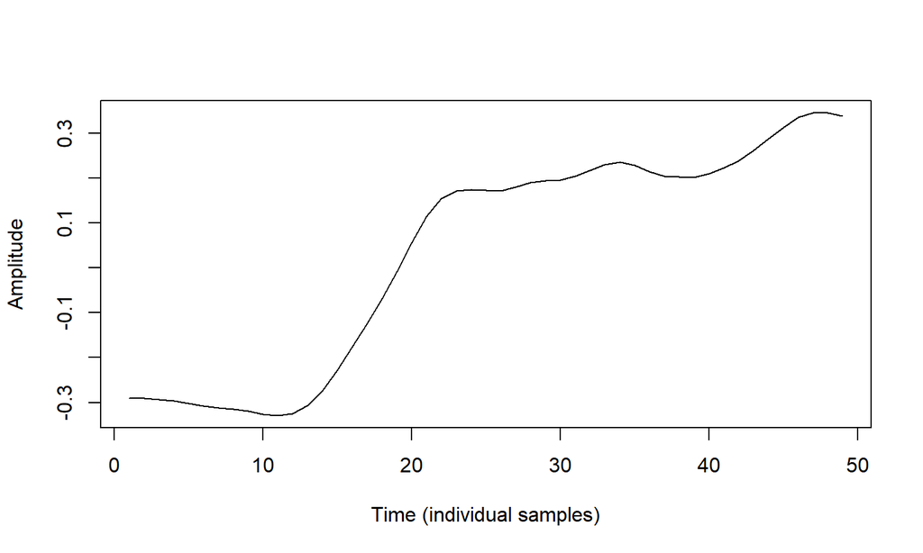

## The procedure: positive VOT

- If we plot the autocorrelation of that smooth interval, it looks like this:

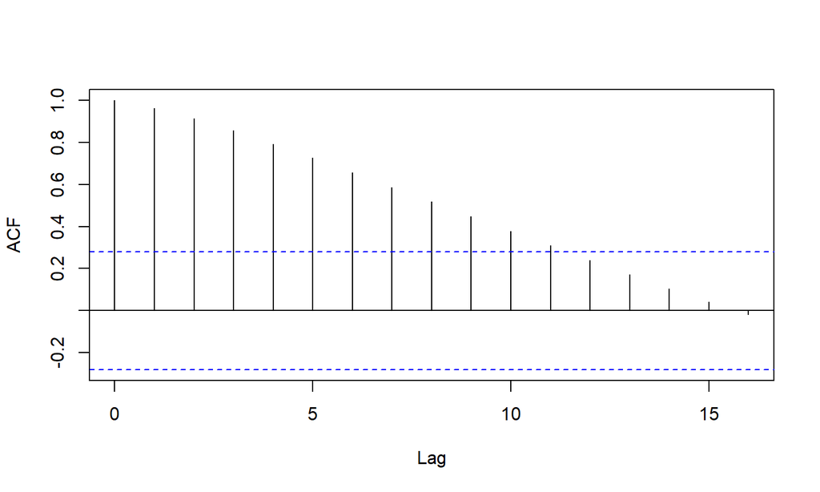

## The procedure: positive VOT

- The interval with the lowest average ACF is this one:

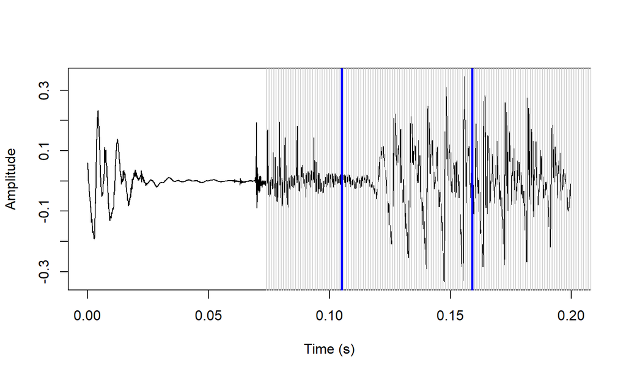

## The procedure: positive VOT

- If we zoom way in, that interval looks like this.
  - It’s very jagged!

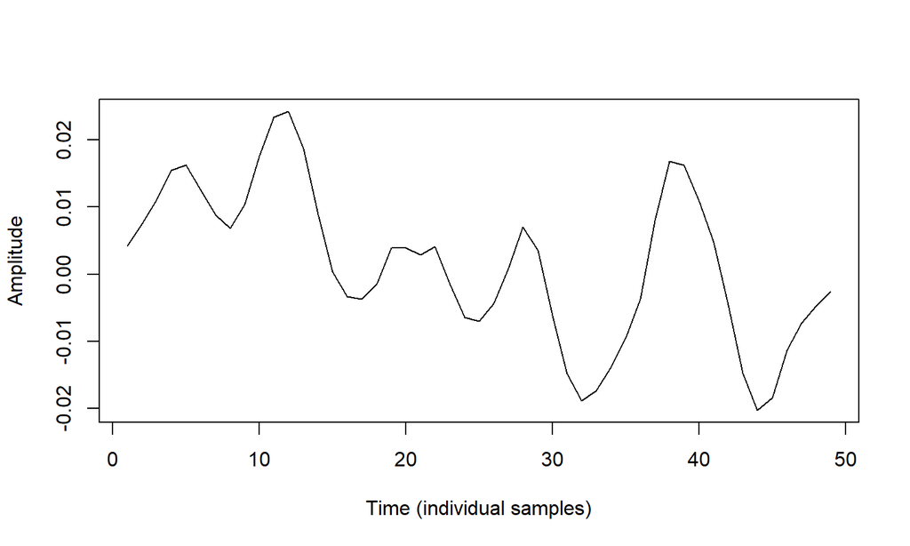

## The procedure: positive VOT

- If we plot the autocorrelation of that jagged interval, it looks like this:

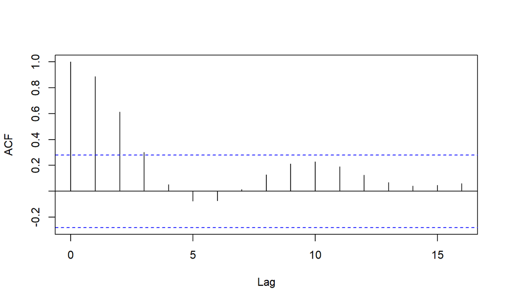

## The procedure: positive VOT

- The first interval where mean ACF comes within 85% of the most autocorrelated interval is this one:

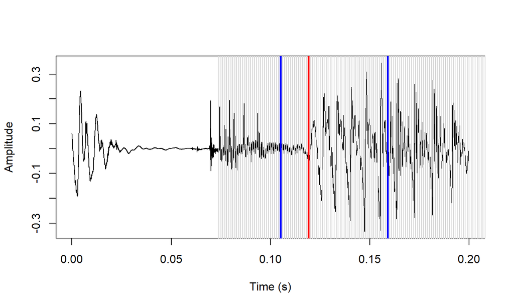

## The procedure: positive VOT

- This was our hand-measured VOT:

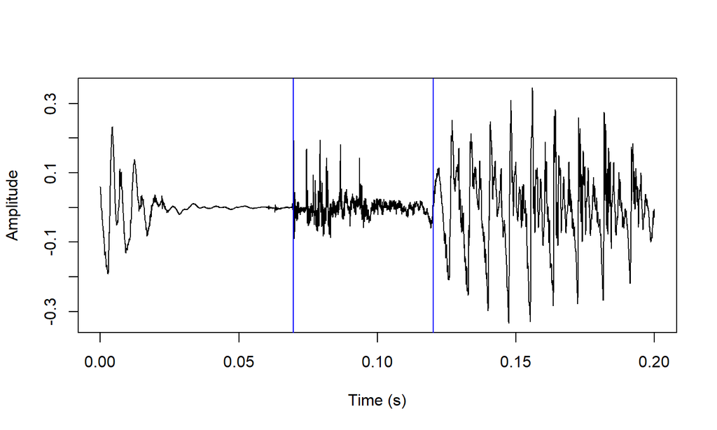

## The procedure: positive VOT

- And this is the VOT that we just predicted:

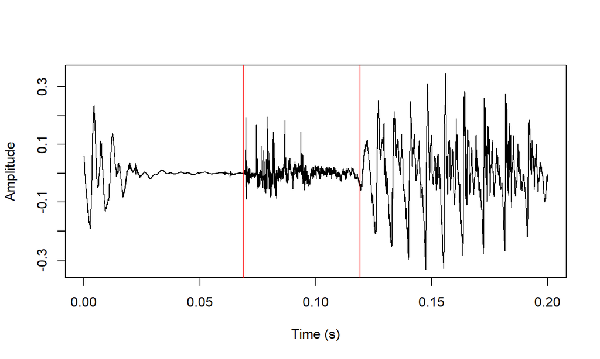

## The procedure: positive VOT

- Pretty good, right?
- Using autocorrelation to predict voicing onset usually gets the best results, but for lower quality audio it’ll rarely work.
- An alternative is using the pitch tracking algorithm from the `phonTools` package.
  - In this case, voicing onset is simply predicted as the first tracked pitch after the release.
- Using amplitude to predict burst location is usually effective, but also won’t work if there’s too much background noise.
  - In this case, burst location can be predicted by first using `phonTools::pitchtrack`.
  - We’ll then first find a stretch of consistently tracked pitch and search for a burst only in the 200 ms preceding.

## The procedure: negative VOT

- When searching for negative VOT, we start as before:
  - In the first half of the sound, look for the most silent interval of duration \(d_{clo}\) (here, 10 ms).

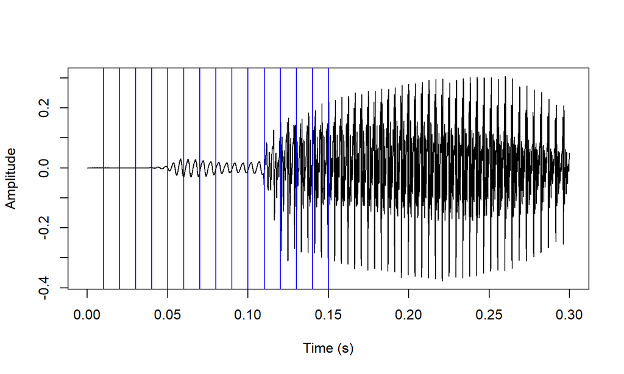

## The procedure: negative VOT

- When searching for negative VOT, we start as before:
  - In the first half of the sound, look for the most silent interval of duration \(d_{clo}\) (here, 10 ms).

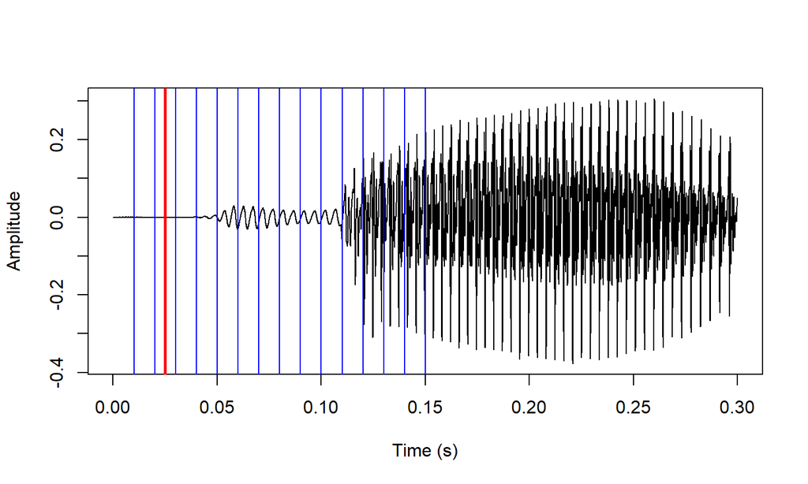

## The procedure: negative VOT

- Next, we partially inverse the process.
- First, we look for voicing using ACF (or alternatively pitch tracking.
  - Which interval of duration \(d_{vo}\) (here, 1.2 ms) is above  
    \(p_{vo}\) % (here, 90%) of the most correlated interval?

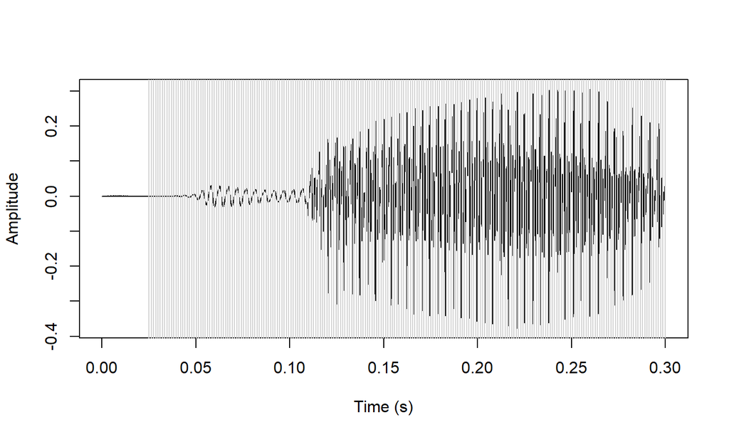

## The procedure: negative VOT

- Next, we partially inverse the process.
- First, we look for voicing using ACF (or alternatively pitch tracking.
  - Which interval of duration \(d_{vo}\) (here, 1.2 ms) is above  
    \(p_{vo}\) % (here, 90%) of the most correlated interval?

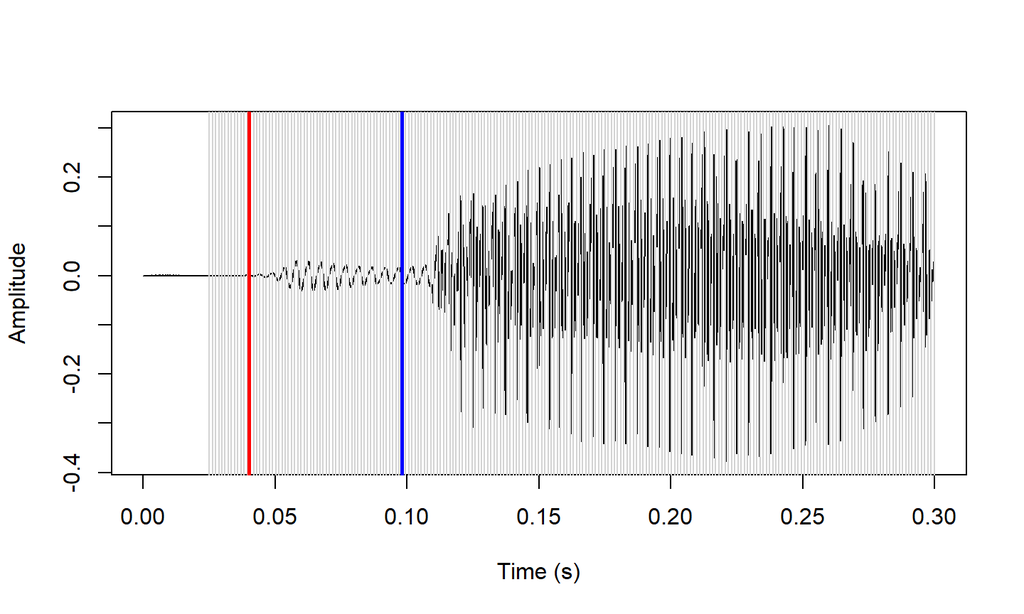

## The procedure: negative VOT

- Finding the release of a pre-voiced stop is rather more difficult.
- The most precise method (but also the most *fickle*) is searching for the *transient phase*.
  - Immediately at the time of a stop release, the compressed air in the oral tract is discharged.
  - This results in a fairly even distribution of energy throughout the spectrum (see e.g. Stevens 1993).
  - Such smooth, even spectra are otherwise not found in speech.
  - They’re tricky to find automatically as they’re very short!

## The procedure: negative VOT

- Using `phonTools`, we generate spectra with a duration of 1 ms in windows of 10 samples.
- Spectral smoothness is calculated by taking the standard deviation of the difference among adjacent amplitude measures in each spectrum.

## The procedure: negative VOT

- For reference, this is an example of a rather jagged spectrum.

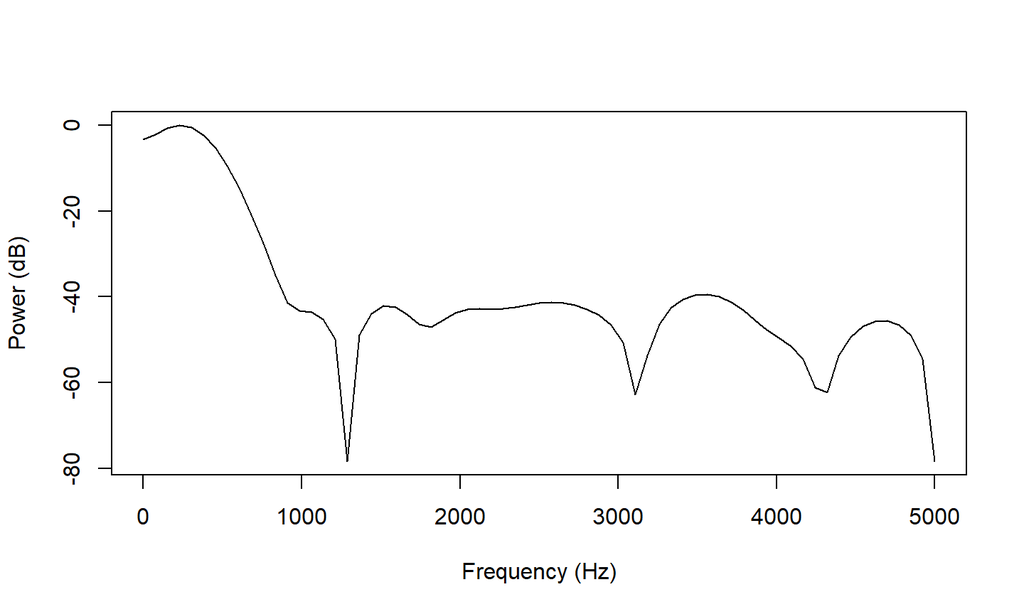

## The procedure: negative VOT

- In general, the difference between adjacent amplitude measures is relatively high.
- Let’s plot this!

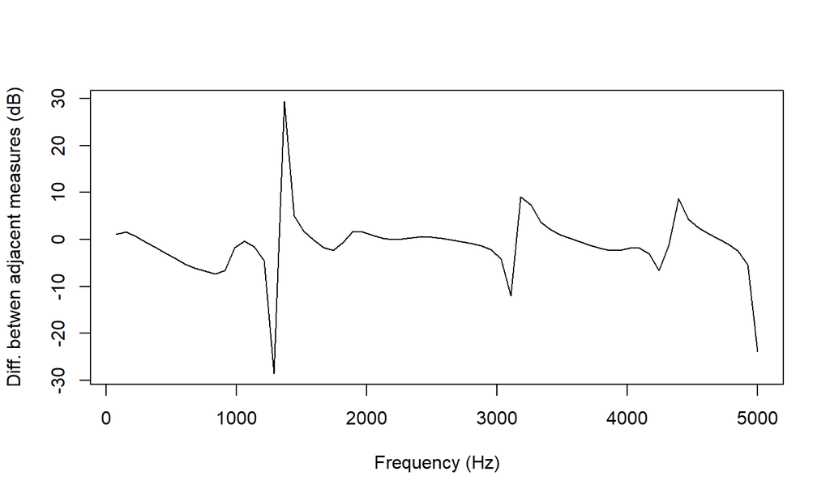

## The procedure: negative VOT

- On the other hand, this is the smoothest spectrum:

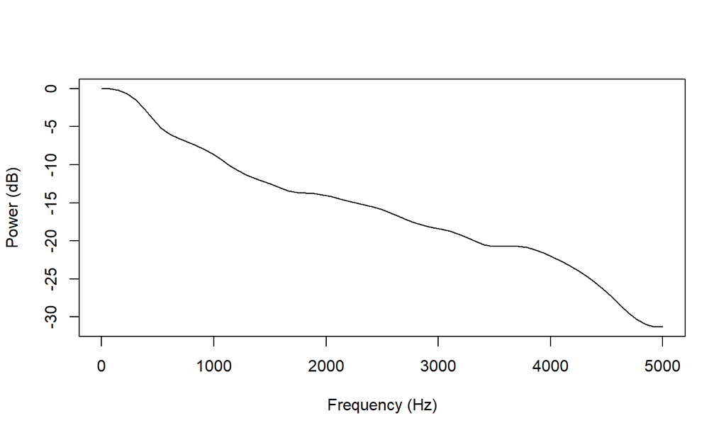

## The procedure: negative VOT

- This is immediately clear when plotting the difference between adjacent measures.

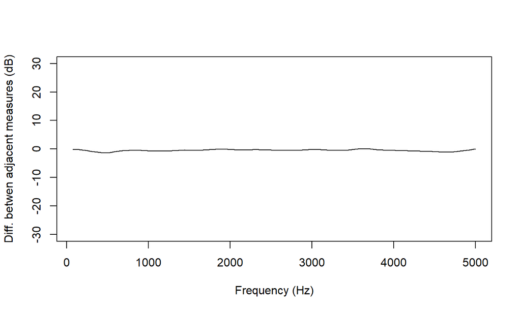

## The procedure: negative VOT

- This is the location of that very smooth spectrum:

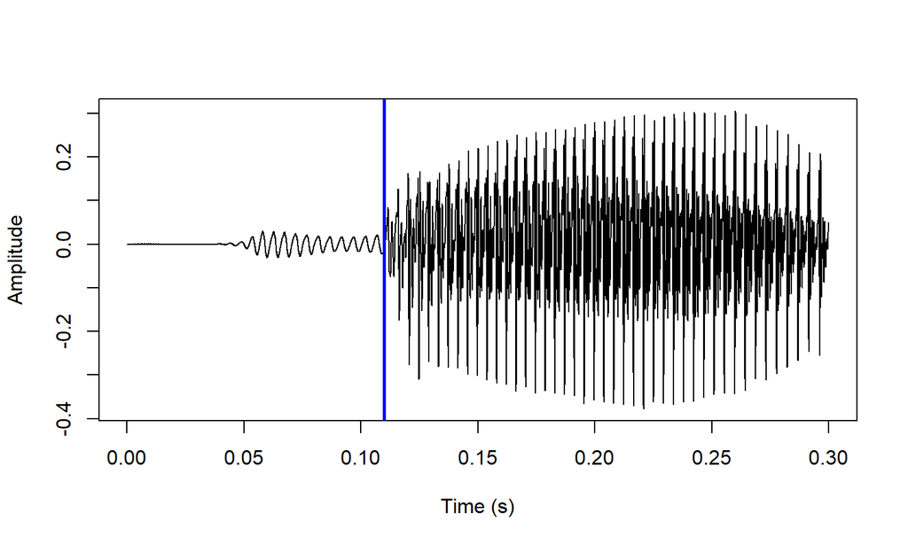

## The procedure: negative VOT

- When it works, this method for finding the release of voiced stops is very precise.
- It’s fickle though, and only works when the sound quality is rather good.
- An alternative method is looking for sudden amplitude increases.